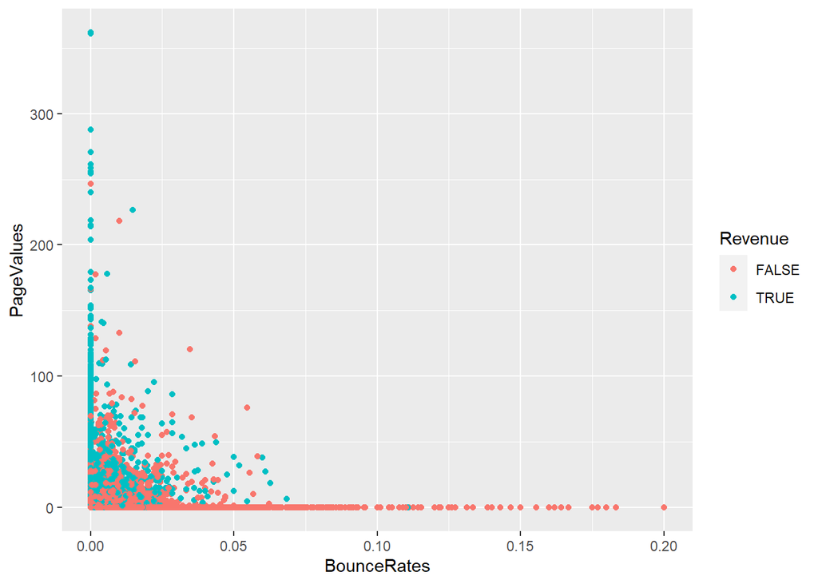

```r
#scatter plot of bouncerates and pagevalues
ggplot(data = shoppers) +
  geom_point(mapping = aes(x = BounceRates, y = PageValues, color = Revenue))
```

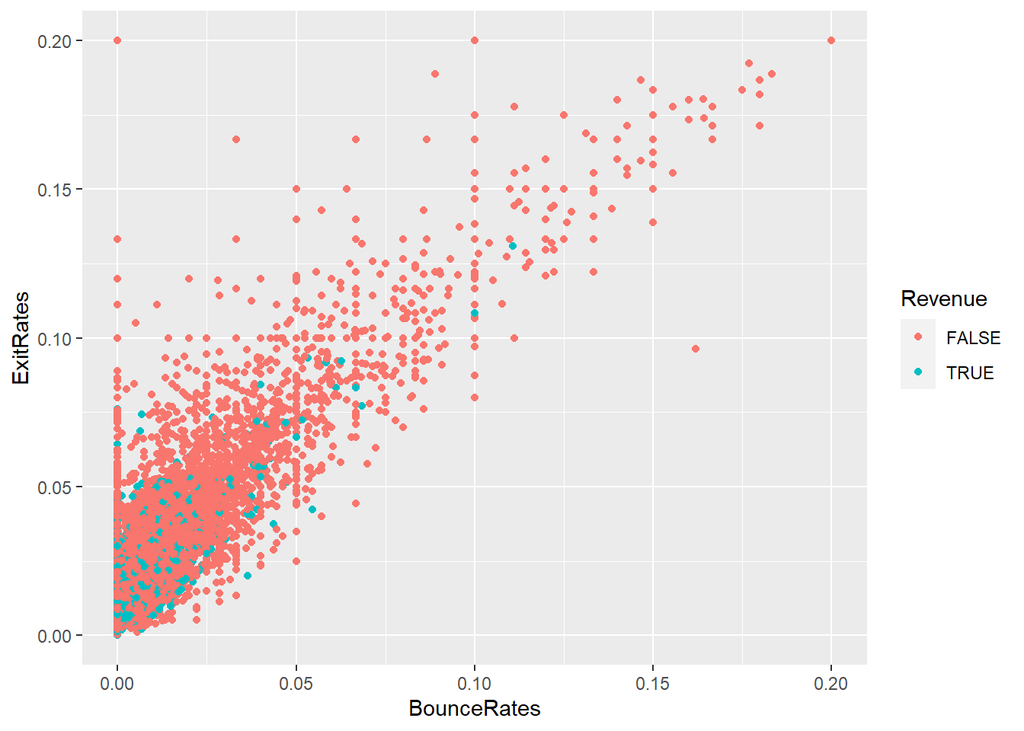

```r
#scatter plot of bouncerates and exitrates
ggplot(data = shoppers) +
  geom_point(mapping = aes(x = BounceRates, y = ExitRates, color = Revenue))
```

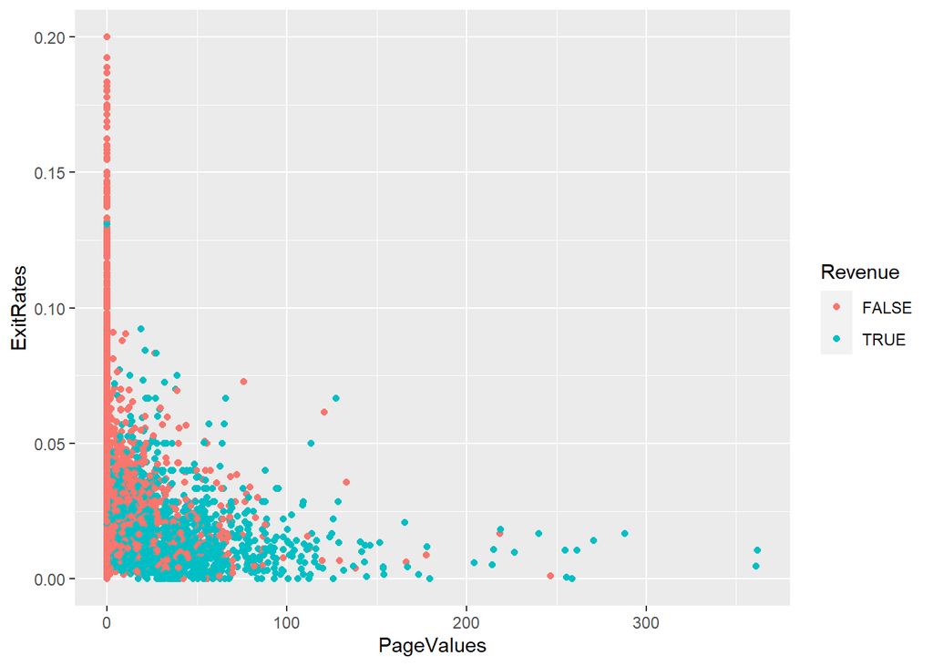

```r
#scatter plot of pagevalues and exitrates
ggplot(data = shoppers) +
  geom_point(mapping = aes(x = PageValues, y = ExitRates, color = Revenue))
```

*Observations*

Bouncerates and exitrates have a strong linear relationship. More revenue is generated with more pagevalues

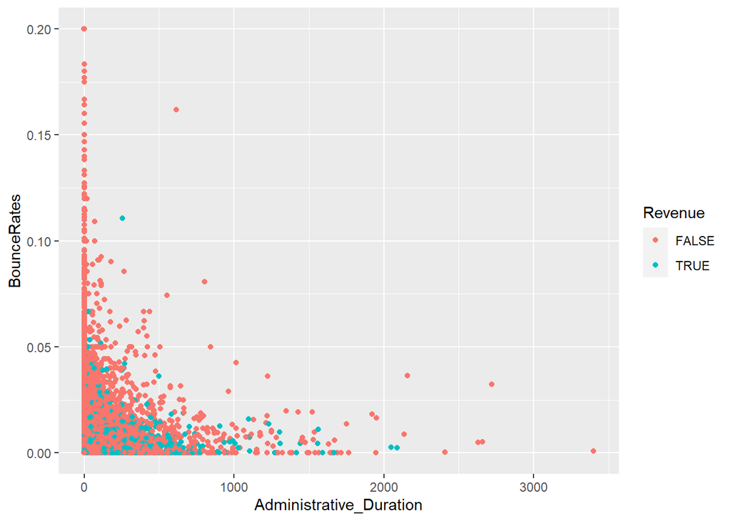

```r
#scatter plot of duration spent on administrative duration, bouncerates and exit rates
ggplot(data = shoppers) +
  geom_point(mapping = aes(x = Administrative_Duration, y = BounceRates, color = Revenue))
```

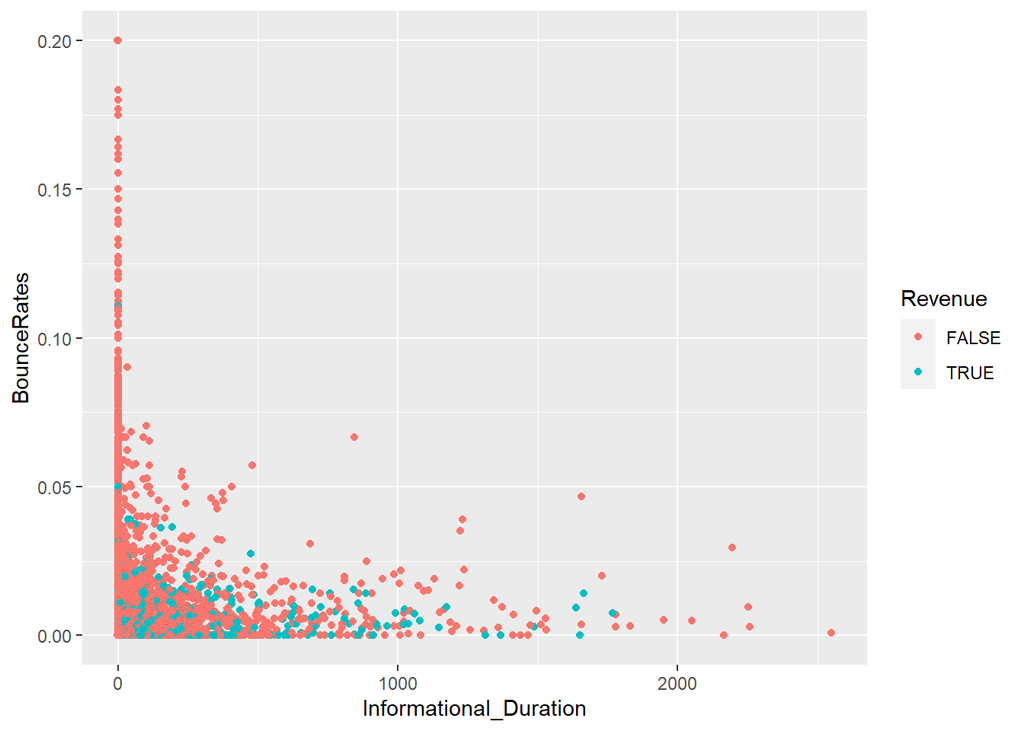

```r
#scatter plot of duration spent on informational duration and bouncerates
ggplot(data = shoppers) +
  geom_point(mapping = aes(x = Informational_Duration, y = BounceRates, color = Revenue))
```

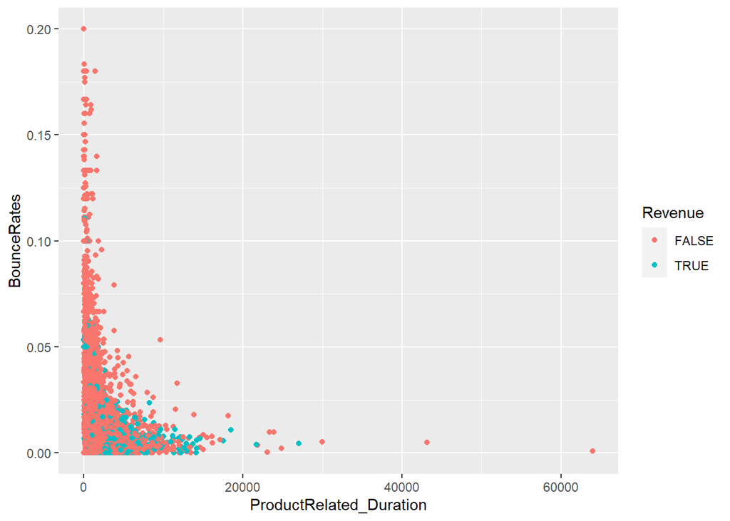

```r
#scatter plot of duration spent on product related duration and bouncerates
ggplot(data = shoppers) +
  geom_point(mapping = aes(x = ProductRelated_Duration, y = BounceRates, color = Revenue))
```

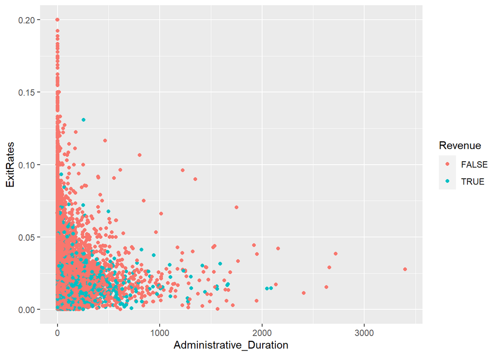

```r
#scatter plot of duration spent on administrative duration and exit rates
ggplot(data = shoppers) +
  geom_point(mapping = aes(x = Administrative_Duration, y = ExitRates, color = Revenue))
```

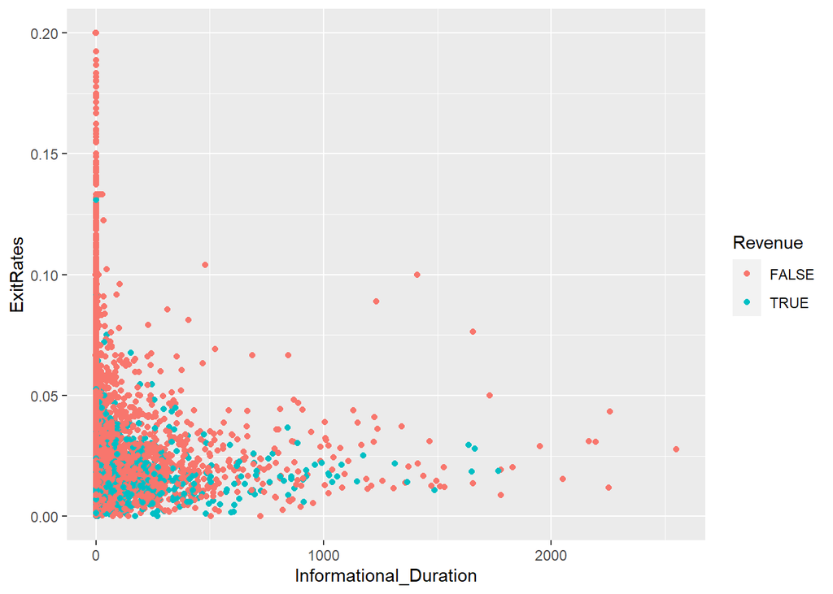

```r
#scatter plot of duration spent on informational duration and exitrates
ggplot(data = shoppers) +
  geom_point(mapping = aes(x = Informational_Duration, y = ExitRates, color = Revenue))
```

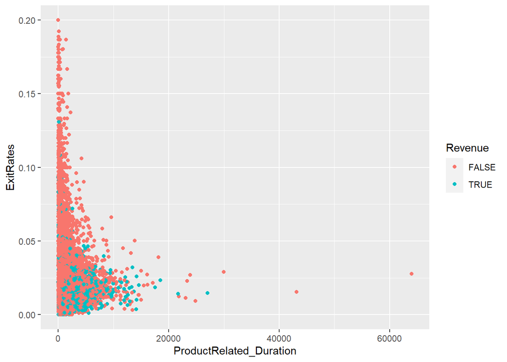

```r
#scatter plot of duration spent on product related duration and exitrates
ggplot(data = shoppers) +
  geom_point(mapping = aes(x = ProductRelated_Duration, y = ExitRates, color = Revenue))
```

*Observations*

There is no visible linear relationship between the duration spent on the pages and the bounce rates. However, Most of the revenue generated was from lower bounce rates and more duration on the pages

There is no visible linear relationship between the duration spent on the pages and the exit rates. Most of the revenue generated was from more time spent on the pages and less exit rates

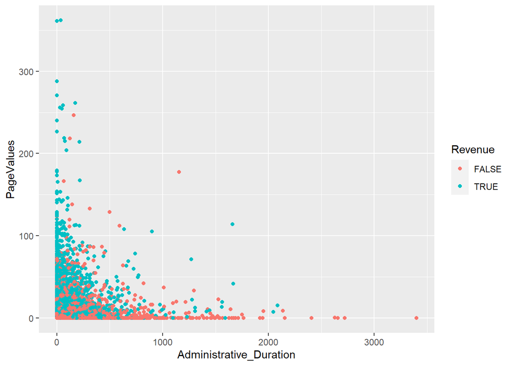

```r
#scatterplots of pagevalues and the duration on the pages
#scatter plot of administrative pages and the pagevalues
ggplot(data = shoppers) +
  geom_point(mapping = aes (x = Administrative_Duration, y = PageValues, color = Revenue))
```

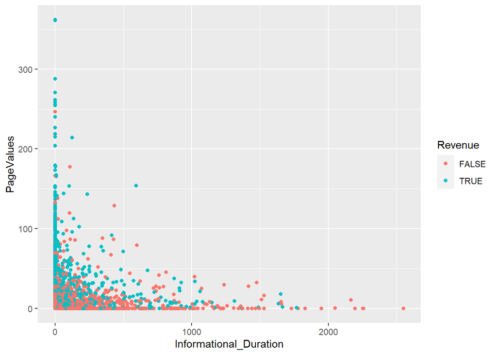

```r
#scatter plot of informational pages and pagevalues
ggplot(data = shoppers) +
  geom_point(mapping = aes(x = Informational_Duration, y = PageValues, color = Revenue))
```

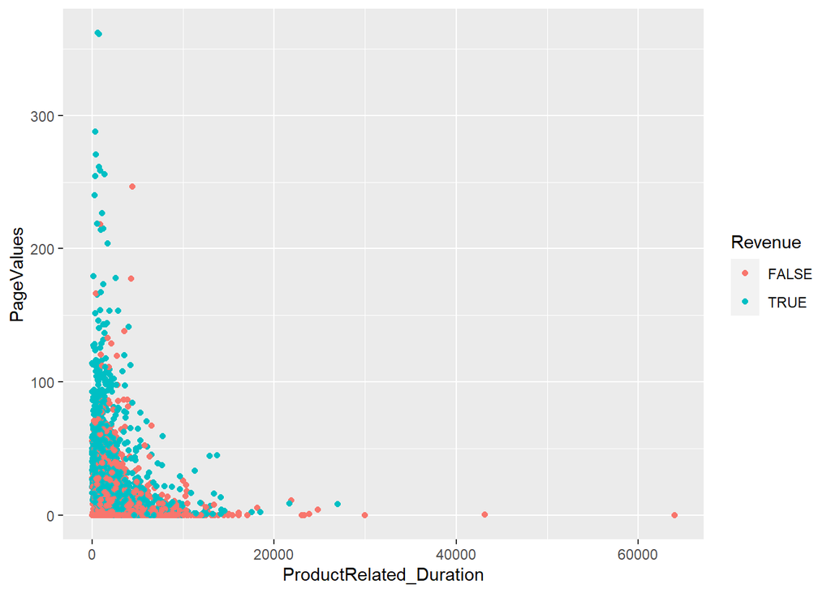

```r
#scatter plot of productrelated pages and pagevalues
ggplot(data = shoppers) +
  geom_point(mapping = aes(x = ProductRelated_Duration, y = PageValues, color = Revenue))
```

*Observations*

There is no visible linear relationship between these variables, however, most of the revenue is generated from with a high page value regardless of the duration spent on a specific page

```r
library(GGally)
```

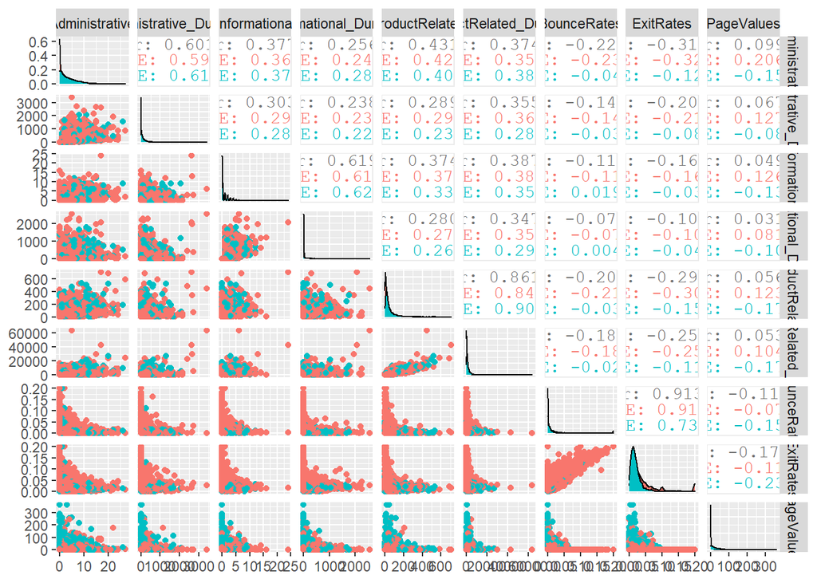

```r
# scatter plots of all the numerical variables
ggpairs(shoppers, columns = c(1:9), ggplot2::aes(colour=Revenue))
```

## Implementing the Solution

### Data Pre-processing

```r
library(plyr)
library(dplyr)
library(caret)
```

```r
#factor variables to ordinal features

#viweing the order of the specialday variable
print(table(shoppers$SpecialDay))
```

```
##
##     0   0.2   0.4   0.6   0.8     1
## 11065   178   243   351   325   154
```

```r
#Specialday variable to ordinal features
shoppers$SpecialDay <- factor(shoppers$SpecialDay, order = TRUE, levels = c(0,0.2,0.4,0.6,0.8,1))

#viweing the order of the operating systems variable
print(table(shoppers$OperatingSystems))
```

```
##
##    1    2    3    4    5    6    7    8
## 2582 6593 2552  478    6   19    7   79
```

```r
#OperatingSystems variable to ordinal features
shoppers$OperatingSystems <- factor(shoppers$OperatingSystems, order = TRUE, levels = c(6,3,7,1,5,2,4,8))

#viewing the order of the browser variable
print(table(shoppers$Browser))
```

```
##
##    1    2    3    4    5    6    7    8    9   10   11   12   13
## 2459 7951  105  735  467  174   49  135    1  163    6   10   61
```

```r
#browser variable to ordinal features
shoppers$Browser <- factor(shoppers$Browser, order = TRUE, levels = c(9,3,6,7,1,2,8,11,4,5,10,13,12))

#viewing the order of the region variable
print(table(shoppers$Region))
```

```
##
##    1    2    3    4    5    6    7    8    9
## 4774 1134 2402 1179  317  804  761  434  511
```

```r
#region variable to ordinal features
shoppers$Region <- factor(shoppers$Region, order = TRUE, levels = c(8,6,3,4,7,1,5,2,9))

#viewing the order of the traffic type variable
print(table(shoppers$TrafficType))
```

```
##
##    1    2    3    4    5    6    7    8    9   10   11   12   13   14   15   16
## 2444 3909 2051 1069  260  444   40  343   42  450  247    1  737   13   37    3
##   17   18   19   20
##    1   10   17  198
```

```r
#traffictype variable to ordinal features
shoppers$TrafficType <- factor(shoppers$TrafficType, order = TRUE, levels = c(12,15,17,18,13,19,3,9,1,6,4,14,11,10,5,2,20,8,7,16))
```

```r
#checking the levels in the two character columns (visitor type and month)
print(table(shoppers$Month))
```

```
##
##  Aug  Dec  Feb  Jul June  Mar  May  Nov  Oct  Sep
##  433 1727  184  432  288 1894 3363 2998  549  448
```

```r
print(table(shoppers$VisitorType))
```

```
##
##       New_Visitor             Other Returning_Visitor
##              1694                85             10537
```

```r
#encoding character variables visitor type and month
shoppers$Month <- factor(shoppers$Month, order = TRUE, levels =c('Feb', 'Mar', 'May', 'June','Jul', 'Aug', 'Sep','Oct', 'Nov','Dec'))
shoppers$Month_Numeric <-mapvalues(shoppers$Month, from = c('Feb', 'Mar', 'May', 'June','Jul', 'Aug', 'Sep','Oct', 'Nov','Dec'), to = c(1,2,3,4,5,6,7,8,9,10))


shoppers$VisitorType <- factor(shoppers$VisitorType, order = TRUE, levels = c('Returning_Visitor', 'Other', 'New_Visitor'))
shoppers$VisitorType_Numeric <-mapvalues(shoppers$VisitorType, from = c("Returning_Visitor", "Other", "New_Visitor"), to = c(1,2,3))
```

```r
#converting logical variables (revenue and weekend) to integers
shoppers$Revenue <- ifelse(shoppers$Revenue == "TRUE",1,0)
shoppers$Weekend <- ifelse(shoppers$Weekend == "TRUE", 1,0)

#printing the variabls as a table
print(table(shoppers$Revenue))
```

```
##
##     0     1
## 10408  1908
```

```r
print(table(shoppers$Weekend))
```

```
##
##    0    1
## 9451 2865
```

```r
#normalizing numerical variables
#function to normalize
normalize <- function(x) {
  return ((x - min(x)) / (max(x) - min(x)))
}

# subjectingbthe function to the variables
shoppers$Administrative <- normalize(shoppers$Administrative)
shoppers$Administrative_Duration <- normalize(shoppers$Administrative_Duration)
shoppers$Informational <- normalize(shoppers$Informational_Duration)
shoppers$Informational_Duration <- normalize(shoppers$Administrative)
shoppers$ProductRelated <- normalize(shoppers$ProductRelated)
shoppers$ProductRelated_Duration <- normalize(shoppers$ProductRelated_Duration)
```

```r
#viewing the structure of the encoded variables
str(shoppers)
```

```
## Classes 'data.table' and 'data.frame':   12316 obs. of  20 variables:
##  $ Administrative         : num  0 0 0 0 0 ...
##  $ Administrative_Duration: num  0.000294 0.000294 0 0.000294 0.000294 ...
##  $ Informational          : num  0.000392 0.000392 0 0.000392 0.000392 ...
##  $ Informational_Duration : num  0 0 0 0 0 ...
##  $ ProductRelated         : num  0.00142 0.00284 0.00142 0.00284 0.01418 ...
##  $ ProductRelated_Duration: num  1.56e-05 1.02e-03 0.00 5.73e-05 9.82e-03 ...
##  $ BounceRates            : num  0.2 0 0.2 0.05 0.02 ...
##  $ ExitRates              : num  0.2 0.1 0.2 0.14 0.05 ...
##  $ PageValues             : num  0 0 0 0 0 0 0 0 0 0 ...
##  $ SpecialDay             : Ord.factor w/ 6 levels "0"<"0.2"<"0.4"<..: 1 1 1 1 1 1 3 1 5 3 ...
##  $ Month                  : Ord.factor w/ 10 levels "Feb"<"Mar"<"May"<..: 1 1 1 1 1 1 1 1 1 1 ...
##  $ OperatingSystems       : Ord.factor w/ 8 levels "6"<"3"<"7"<"1"<..: 4 6 7 2 2 6 6 4 6 6 ...
##  $ Browser                : Ord.factor w/ 13 levels "9"<"3"<"6"<"7"<..: 5 6 5 6 2 6 9 6 6 9 ...
##  $ Region                 : Ord.factor w/ 9 levels "8"<"6"<"3"<"4"<..: 6 6 9 8 6 6 3 6 8 6 ...
##  $ TrafficType            : Ord.factor w/ 20 levels "12"<"15"<"17"<..: 9 16 7 11 11 7 7 15 7 16 ...
##  $ VisitorType            : Ord.factor w/ 3 levels "Returning_Visitor"<..: 1 1 1 1 1 1 1 1 1 1 ...
##  $ Weekend                : num  0 0 0 0 1 0 0 1 0 0 ...
##  $ Revenue                : num  0 0 0 0 0 0 0 0 0 0 ...
##  $ Month_Numeric          : Ord.factor w/ 10 levels "1"<"2"<"3"<"4"<..: 1 1 1 1 1 1 1 1 1 1 ...
##  $ VisitorType_Numeric    : Ord.factor w/ 3 levels "1"<"2"<"3": 1 1 1 1 1 1 1 1 1 1 ...
##  - attr(*, ".internal.selfref")=<externalptr>
```

```r
#omitting the month and visitor type columns and retain the month numeric and visitor type numeric

shoppers$Month <- NULL
shoppers$VisitorType <- NULL

#printing the column names to confirm the changes have been made
colnames(shoppers)
```

```
##  [1] "Administrative"          "Administrative_Duration"
##  [3] "Informational"           "Informational_Duration"
##  [5] "ProductRelated"          "ProductRelated_Duration"
##  [7] "BounceRates"             "ExitRates"
##  [9] "PageValues"              "SpecialDay"
## [11] "OperatingSystems"        "Browser"
## [13] "Region"                  "TrafficType"
## [15] "Weekend"                 "Revenue"
## [17] "Month_Numeric"           "VisitorType_Numeric"
```

## K-Means Clustering

K-means clustering is machine learning algorithm used for partitioning observations into a set of k group(clusters), where k is pre-specified by the analyst. k-means is a clustering algorithm that tries to classify observations into mutually exclusive groups (or clusters), such that observations within the same cluster are as similar as possible (high intra-class similarity), whereas observations from different clusters are as dissimilar as possible (low inter-class similarity). In k-means clustering, each cluster is represented by its center (i.e, centroid) which corresponds to the mean of the observation values assigned to the cluster

### Baseline Model

```r
#loading necessary packages
#library(cluster)
#library(factoextra)
```

```r
#preprocessing data for k-means clustering
#we will remove Class Attribute “Revenue” and store it in another variable

shoppers.online<- shoppers[, c(1:15,17:18)]
shoppers.class<- shoppers[, "Revenue"]

#previewing the class attribute
head(shoppers.class)
```

```
##    Revenue
## 1:       0
## 2:       0
## 3:       0
## 4:       0
## 5:       0
## 6:       0
```

```r
#applying k-means clustering algorithm with number of centres (k=2)

set.seed(123)  #for reproducibility

shoppers_k <- kmeans(shoppers.online, centers = 2)
print(shoppers_k)
```

```
## K-means clustering with 2 clusters of sizes 11626, 690
##
## Cluster means:
##   Administrative Administrative_Duration Informational Informational_Duration
## 1     0.08454231              0.02367327    0.01391324             0.08454231
## 2     0.10778315              0.03114411    0.01407014             0.10778315
##   ProductRelated ProductRelated_Duration BounceRates  ExitRates PageValues
## 1     0.04487386              0.01859847 0.023286480 0.04467122   2.296444
## 2     0.04810977              0.02060975 0.003045071 0.01488644  66.545058
##   SpecialDay OperatingSystems  Browser   Region TrafficType   Weekend
## 1 0.06435575         2.123000 2.345605 3.150353    4.060984 0.2318940
## 2 0.01333333         2.143478 2.559420 3.108696    4.230435 0.2449275
##   Month_Numeric VisitorType_Numeric
## 1      5.778772            1.263031
## 2      6.618841            1.601449
```

[output cut: 354 more lines]

```r
#to visualize our clusters, we will convert all our variables to numerical variables
str(shoppers)
```

```
## Classes 'data.table' and 'data.frame':   12316 obs. of  18 variables:
##  $ Administrative         : num  0 0 0 0 0 ...
##  $ Administrative_Duration: num  0.000294 0.000294 0 0.000294 0.000294 ...
##  $ Informational          : num  0.000392 0.000392 0 0.000392 0.000392 ...
##  $ Informational_Duration : num  0 0 0 0 0 ...
##  $ ProductRelated         : num  0.00142 0.00284 0.00142 0.00284 0.01418 ...
##  $ ProductRelated_Duration: num  1.56e-05 1.02e-03 0.00 5.73e-05 9.82e-03 ...
##  $ BounceRates            : num  0.2 0 0.2 0.05 0.02 ...
##  $ ExitRates              : num  0.2 0.1 0.2 0.14 0.05 ...
##  $ PageValues             : num  0 0 0 0 0 0 0 0 0 0 ...
##  $ SpecialDay             : Ord.factor w/ 6 levels "0"<"0.2"<"0.4"<..: 1 1 1 1 1 1 3 1 5 3 ...
##  $ OperatingSystems       : Ord.factor w/ 8 levels "6"<"3"<"7"<"1"<..: 4 6 7 2 2 6 6 4 6 6 ...
##  $ Browser                : Ord.factor w/ 13 levels "9"<"3"<"6"<"7"<..: 5 6 5 6 2 6 9 6 6 9 ...
##  $ Region                 : Ord.factor w/ 9 levels "8"<"6"<"3"<"4"<..: 6 6 9 8 6 6 3 6 8 6 ...
##  $ TrafficType            : Ord.factor w/ 20 levels "12"<"15"<"17"<..: 9 16 7 11 11 7 7 15 7 16 ...
##  $ Weekend                : num  0 0 0 0 1 0 0 1 0 0 ...
##  $ Revenue                : num  0 0 0 0 0 0 0 0 0 0 ...
##  $ Month_Numeric          : Ord.factor w/ 10 levels "1"<"2"<"3"<"4"<..: 1 1 1 1 1 1 1 1 1 1 ...
##  $ VisitorType_Numeric    : Ord.factor w/ 3 levels "1"<"2"<"3": 1 1 1 1 1 1 1 1 1 1 ...
##  - attr(*, ".internal.selfref")=<externalptr>
```

```r
#creating columns for a dataframe with all numeric values

administrative <- shoppers$Administrative
administrative.duration <- shoppers$Administrative_Duration
informational <- shoppers$Informational
informational.duration <- shoppers$Informational_Duration
productrelated <- shoppers$ProductRelated
productrelated.duration <- shoppers$ProductRelated_Duration
bouncerates <- shoppers$BounceRates
exitrates<- shoppers$ExitRates
pagevalues <- shoppers$PageValues
specialday.numeric <- as.numeric(shoppers$SpecialDay)
operatingsystems.numeric <- as.numeric(shoppers$OperatingSystems)
browser.numeric <- as.numeric(shoppers$Browser)
region.numeric <- as.numeric(shoppers$Region)
traffic.numeric <- as.numeric(shoppers$TrafficType)
weekend.numeric <- as.numeric(shoppers$Weekend)
month.numeric <- as.numeric(shoppers$Month_Numeric)
visitors.numeric <- as.numeric(shoppers$VisitorType_Numeric)
```

```r
#create a new dataframe (shoppers.numeric)with numeric features only

shoppers.numeric <- data.frame(administrative, administrative.duration, informational, informational.duration, productrelated, productrelated.duration, bouncerates, exitrates, pagevalues, specialday.numeric, operatingsystems.numeric, browser.numeric, region.numeric, traffic.numeric, weekend.numeric, month.numeric, visitors.numeric)

head(shoppers.numeric)
```

```
##   administrative administrative.duration informational informational.duration
## 1              0            0.0002941393  0.0003920992                      0
## 2              0            0.0002941393  0.0003920992                      0
## 3              0            0.0000000000  0.0000000000                      0
## 4              0            0.0002941393  0.0003920992                      0
## 5              0            0.0002941393  0.0003920992                      0
## 6              0            0.0002941393  0.0003920992                      0
##   productrelated productrelated.duration bouncerates exitrates pagevalues
## 1    0.001418440            1.563122e-05  0.20000000 0.2000000          0
## 2    0.002836879            1.016029e-03  0.00000000 0.1000000          0
## 3    0.001418440            0.000000e+00  0.20000000 0.2000000          0
## 4    0.002836879            5.731448e-05  0.05000000 0.1400000          0
## 5    0.014184397            9.824223e-03  0.02000000 0.0500000          0
## 6    0.026950355            2.426226e-03  0.01578947 0.0245614          0
##   specialday.numeric operatingsystems.numeric browser.numeric region.numeric
## 1                  1                        4               5              6
## 2                  1                        6               6              6
## 3                  1                        7               5              9
## 4                  1                        2               6              8
## 5                  1                        2               2              6
## 6                  1                        6               6              6
##   traffic.numeric weekend.numeric month.numeric visitors.numeric
## 1               9               0             1                1
## 2              16               0             1                1
## 3               7               0             1                1
## 4              11               0             1                1
## 5              11               1             1                1
## 6               7               0             1                1
```

```r
#the size of the new data frame
dim(shoppers.numeric)
```

```
## [1] 12316    17
```

```r
# applying k-means clustering on the new dataset to visualize the  clustering results

shoppers_k2 <- kmeans(shoppers.online, centers = 2)
print(shoppers_k2)
```

```
## K-means clustering with 2 clusters of sizes 690, 11626
##
## Cluster means:
##   Administrative Administrative_Duration Informational Informational_Duration
## 1     0.10778315              0.03114411    0.01407014             0.10778315
## 2     0.08454231              0.02367327    0.01391324             0.08454231
##   ProductRelated ProductRelated_Duration BounceRates  ExitRates PageValues
## 1     0.04810977              0.02060975 0.003045071 0.01488644  66.545058
## 2     0.04487386              0.01859847 0.023286480 0.04467122   2.296444
##   SpecialDay OperatingSystems  Browser   Region TrafficType   Weekend
## 1 0.01333333         2.143478 2.559420 3.108696    4.230435 0.2449275
## 2 0.06435575         2.123000 2.345605 3.150353    4.060984 0.2318940
##   Month_Numeric VisitorType_Numeric
## 1      6.618841            1.601449
## 2      5.778772            1.263031
```

[output cut: 354 more lines]

```r
# Cluster size
shoppers_k2$size
```

```
## [1]   690 11626
```

```r
# Between clusters sum of square
shoppers_k2$betweenss
```

```
## [1] 2689256
```

The sum of squares between the two clusters is 2.689256^{6}

```r
# Within cluster sum of square
shoppers_k2$withinss
```

```
## [1] 1131972  879050
```

The sum of squares within each cluster is 1.1319724^{6}, 8.7905003^{5}

```r
# Total with sum of square
shoppers_k2$tot.withinss
```

```
## [1] 2011022
```

The total sum of squares within both clusters is 2.0110224^{6}

```r
# Total sum of square
shoppers_k2$totss
```

```
## [1] 4700278
```

The total sum of squares obtained from clustering the entire dataset is 4.7002784^{6}

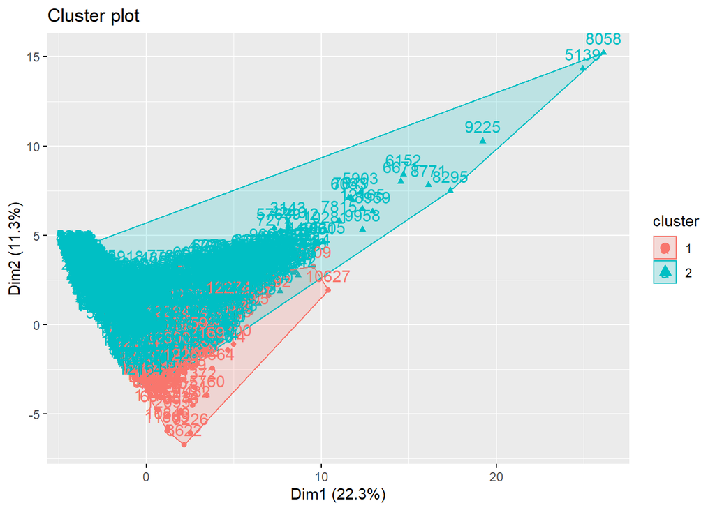

```r
#visualizing the clusters
fviz_cluster(shoppers_k2, data = shoppers.numeric)
```

### Optimizing k-means Algorithm

For k-means algorithm, the number of clusters is pre-specified by the analyst, for this study, we have been given the class variable - Revenue, which has two classes which is a clear indication that we will have two clusters. However, for datasets that do Not have clear classes, it is not possible to know the optimal number of k hence, we can find the optimal number of k by creating a plot of the total sums of squares within-groups against the number of clusters. A bend in the graph can suggest the appropriate number of clusters in that dataset.

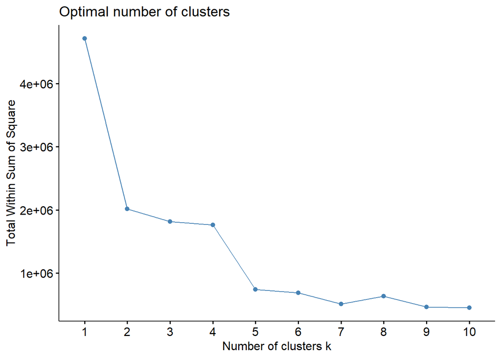

```r
# finding the optimal number of clusters

fviz_nbclust(x = shoppers.numeric,FUNcluster = kmeans, method = 'wss' )
```

The Elbow method shows two points that could be the optimal number of k’s, 2 and 5. An alternative method is the silhoutte method

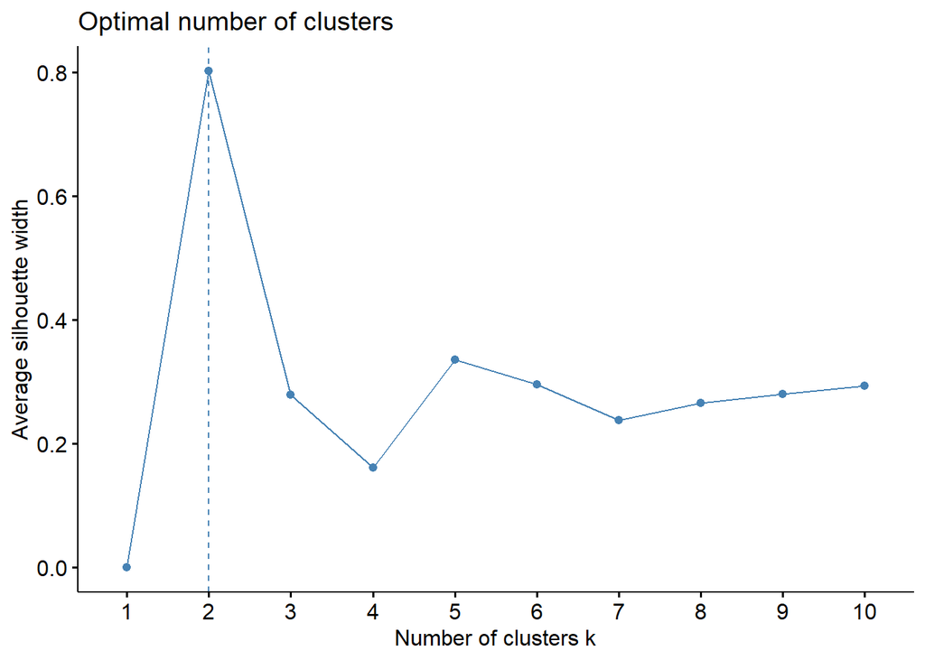

```r
# Determining Optimal clusters (k) Using Average Silhouette Method

fviz_nbclust(x = shoppers.numeric,FUNcluster = kmeans, method = 'silhouette' )
```

The silhoutte method shows the optimal number of k is 2.

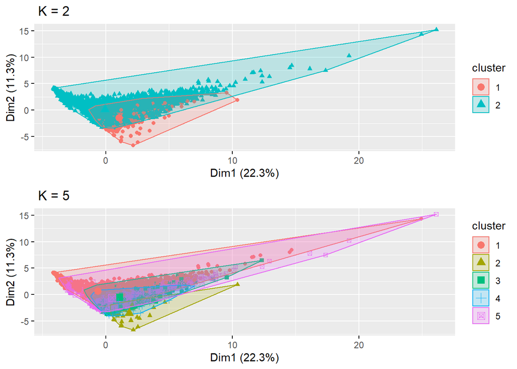

```r
#applying k-means algorithm as with k = 2 and k =5 as had been suggested by the elbow method to see how the two vary
shoppers_k2 <- kmeans(shoppers.numeric, centers = 2)
shoppers_k5 <- kmeans(shoppers.numeric, centers = 5)

p1 <- fviz_cluster(shoppers_k2, geom = "point", data = shoppers.numeric) + ggtitle(" K = 2")
p2 <- fviz_cluster(shoppers_k5, geom = "point", data = shoppers.numeric) + ggtitle(" K = 5")

library(gridExtra)
grid.arrange(p1, p2, nrow = 2)
```

Clearly the optimal number of k’s to use is 2 hence we will work with that

```r
#setting number of random starts to 25
shoppers_k3 <- kmeans(shoppers.numeric, centers = 2, nstart = 25)
print(shoppers_k3)
```

```
## K-means clustering with 2 clusters of sizes 11625, 691
##
## Cluster means:
##   administrative administrative.duration informational informational.duration
## 1     0.08453684              0.02367440    0.01391883             0.08453684
## 2     0.10784156              0.03111429    0.01397587             0.10784156
##   productrelated productrelated.duration bouncerates  exitrates pagevalues
## 1     0.04487077              0.01859825 0.023289199 0.04467452   2.293721
## 2     0.04815716              0.02061050 0.003028623 0.01487411  66.497895
##   specialday.numeric operatingsystems.numeric browser.numeric region.numeric
## 1           1.322151                 4.764645        6.147527       5.043613
## 2           1.060781                 5.280753        6.364689       5.312590
##   traffic.numeric weekend.numeric month.numeric visitors.numeric
## 1        11.51587       0.2319140      5.777892         1.262882
## 2        13.59190       0.2445731      6.632417         1.603473
```

[output cut: 354 more lines]

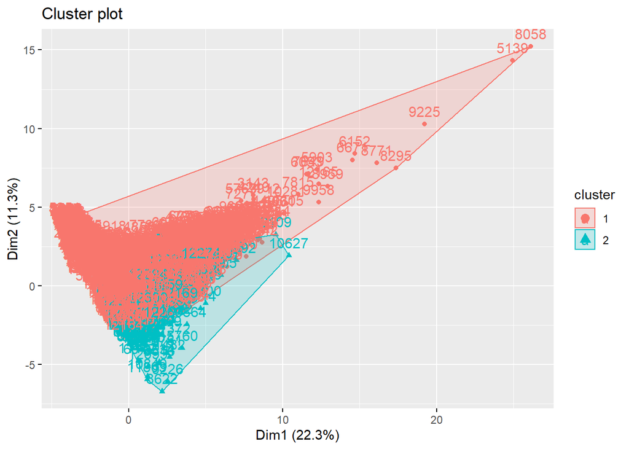

```r
#visualizing the clusters
fviz_cluster(shoppers_k3, data = shoppers.numeric)
```

```r
#descriptive statistics (mean) at the cluster level

shoppers.numeric %>%
  mutate(Cluster = shoppers_k3$cluster) %>%
  group_by(Cluster) %>%
  summarize_all('mean')
```

```
## # A tibble: 2 x 18
##   Cluster administrative administrative.~ informational informational.d~
##     <int>          <dbl>            <dbl>         <dbl>            <dbl>
## 1       1         0.0845           0.0237        0.0139           0.0845
## 2       2         0.108            0.0311        0.0140           0.108
## # ... with 13 more variables: productrelated <dbl>,
## #   productrelated.duration <dbl>, bouncerates <dbl>, exitrates <dbl>,
## #   pagevalues <dbl>, specialday.numeric <dbl>, operatingsystems.numeric <dbl>,
## #   browser.numeric <dbl>, region.numeric <dbl>, traffic.numeric <dbl>,
## #   weekend.numeric <dbl>, month.numeric <dbl>, visitors.numeric <dbl>
```

**Notes from k-means clustering**

Some advantages of k-means clustering we have observed are:

- It’s quite easy to implement
- The algorithm was computationally faster

Some disadvantages are:

*The number of clusters has to be defined from the beginning and we would not know how many clusters we should have

## Hierarchical Clustering

Hierarchical clustering is also a type of unsupervised machine learning algorithm that builds a hierarchy of clusters i.e tree type strucure based in hierarchy that helps solve the disadvantage mentioned above from k-means clustering.

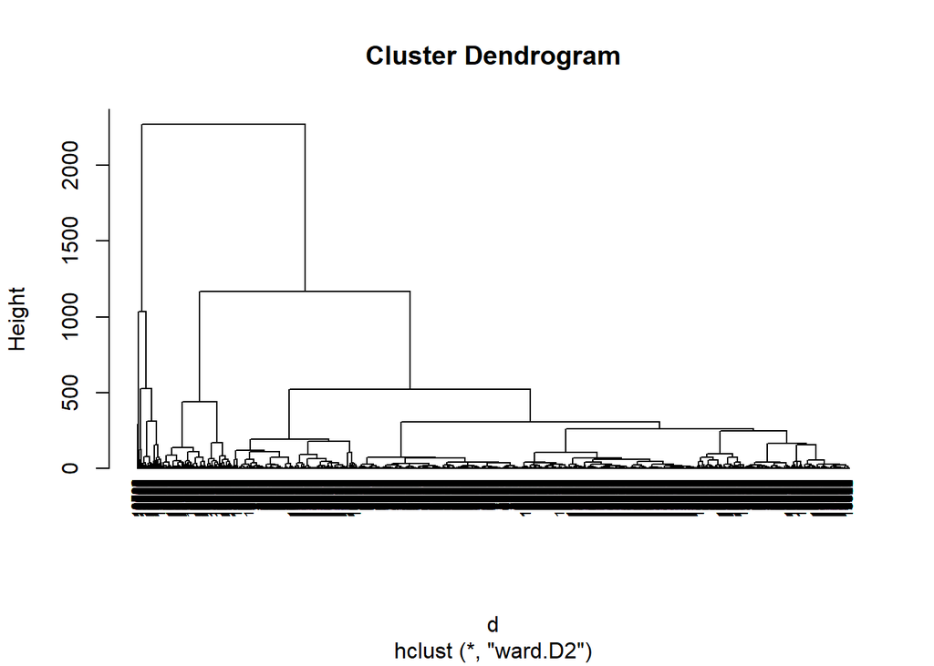

```r
# We use the R function hclust() for hierarchical clustering
#

set.seed(123)  #for reproducibility

# First we use the dist() function to compute the Euclidean distance between observations
d <- dist(shoppers, method = "euclidean")

# We apply hierarchical clustering algorithim using the complete method
shoppers.hc <- hclust(d, method = "ward.D2" )

#plotting a dendrogram
plot(shoppers.hc, cex = 0.6, hang = -1)
```

Our Dendrogram is messy hence we will try to use different approaches to obtain features from it

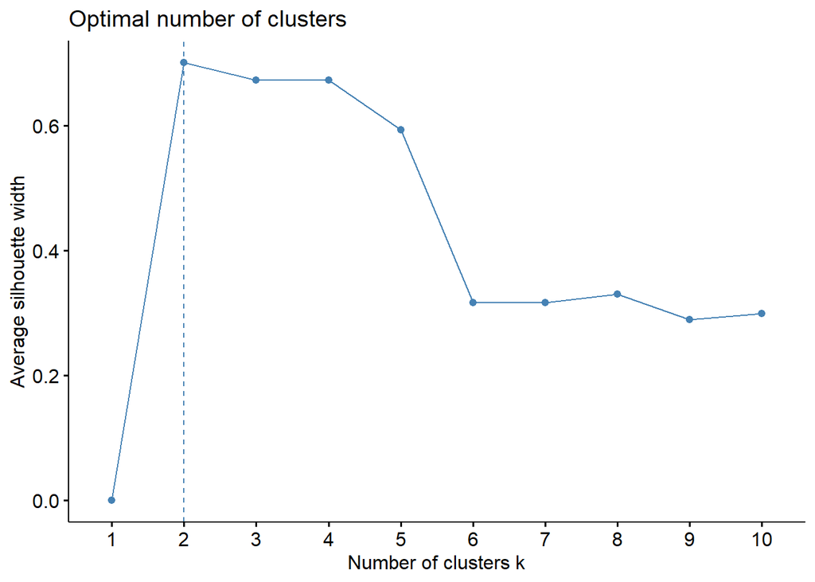

```r
#Determine the optimal k
fviz_nbclust(shoppers.numeric, FUN = hcut, method = "silhouette",
                   k.max = 10)
```

The optimal number of clusters is 2, just as we had seen earlier

```r
#obtaining the subgroups from the dendrograms

# Ward's method
#hc5 <- hclust(d, method = "ward.D2" )

# Cut tree into 4 groups
sub_grp <- cutree(shoppers.hc, k = 2)

# Number of members in each cluster
table(sub_grp)
```

```
## sub_grp
##     1     2
## 11894   422
```

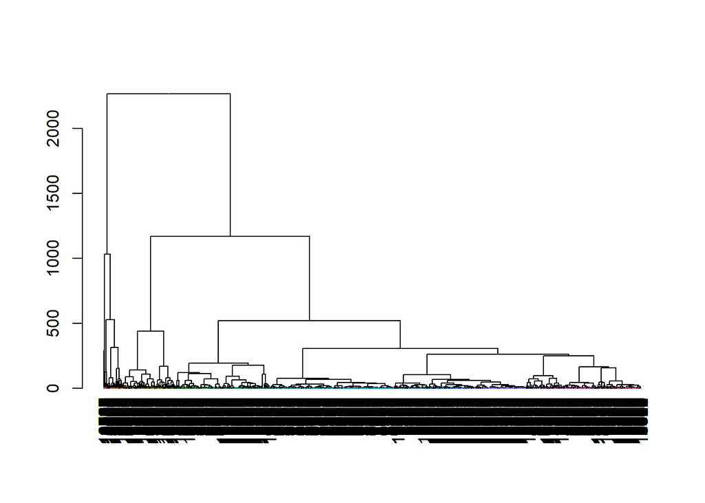

```r
suppressPackageStartupMessages(library(dendextend))
avg_dend_obj <- as.dendrogram(shoppers.hc)
avg_col_dend <- color_branches(avg_dend_obj, h = 2)
plot(avg_col_dend)
```

```r
suppressPackageStartupMessages(library(dplyr))
shoppers_cl <- mutate(shoppers, cluster = sub_grp)
#count(shoppers_cl,cluster)
```

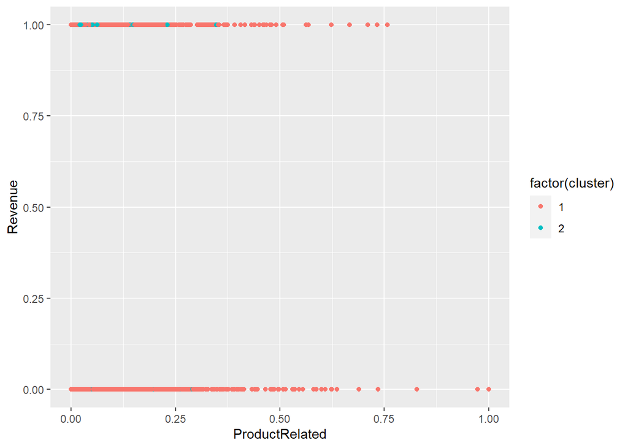

```r
suppressPackageStartupMessages(library(ggplot2))
ggplot(shoppers_cl, aes(x=ProductRelated, y = Revenue, color = factor(cluster))) + geom_point()
```

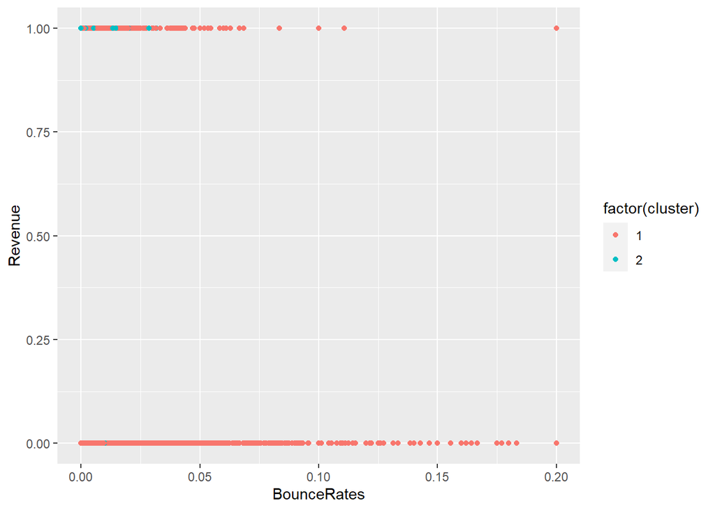

```r
#visualizing the clusters generated using a plot of bouncerates and revenue
ggplot(shoppers_cl, aes(x=BounceRates, y = Revenue, color = factor(cluster))) + geom_point()
```

```r
#creating a confusion matrix to compare the actual classes and the predicted classes
table(shoppers_cl$cluster,shoppers$Revenue)
```

```
##
##         0     1
##   1 10330  1564
##   2    78   344
```

**Notes from Hieracrchical Clustering**

Some advantages of hierachical clustering include;

- We did Not need to specify the number of clusters
- The algorithm is also easy to implement
- Output a hierarchy

Some of the disadvantages include;

*For the dendrogram produced, the datapoints were too many hence there was a lot of overlapping. This means that we could not obtain any information from the structure. Any attempts to rectify this were time consuming (as a result of a huge dataset)which means that that this algorithm cannot be used when you have huge data

## 7. Challenging the Solution

From the metrics of success outlined at the beginning of this study, we can consider this study successfull. However, from the Hierarhical clustering, we were not able to make the best use of the algorithm as we could not interprete the dendrogram. In order to rectify this, it would probably be best to obtain samples of the data and use these sapmles to plot the dendrogram.

From both the k-Means clustering and the Hierarchial clustering, we obtained different cluster sizes. It is difficult to tell which of the two clustered the best. However, it is evident that K-means is less computationally expensive than hierarchical clustering and can be run on large datasets within a reasonable time frame.

## 8. Follow up questions

- How can we tell the clustering method that performed better with this particular dataset?

```r
#dend_plot <- fviz_dend(shoppers.hc)                # create full dendogram
#dend_data <- attr(dend_plot, "dendrogram")         # extract plot info
#dend_cuts <- cut(dend_data, h = 70.5)              # cut the dendogram at
                                                   # designated height
# Create sub dendrogram plots
#p1 <- fviz_dend(dend_cuts$lower[[1]])
#p2 <- fviz_dend(dend_cuts$lower[[1]], type = 'circular')

# Side by side plots
#gridExtra::grid.arrange(p1, p2, nrow = 1)
```

```r
#Alternatively, we use the agnes() function as it will help us get the agglomerative coefficient (AC), which measures the amount of clustering structure found

#set.seed(123) # For reproducibility

# Compute maximum or complete linkage clustering with agnes
#shoppers_hc2 <- agnes(shoppers.numeric, method = "ward")

# Agglomerative coefficient
#shoppers_hc2$ac
```